# Project: TMDB Movie Data Analysis

- Introduction
- Data Wrangling
- Exploratory Data Analysis
- Conclusions

## Introduction

The TMDB movie is a dataset that contains helpfull information about movies. In this report I will try to analyse this dataset to answer the following qustions:

- what are the characteristics that make a movie has higher revenues?
- what are the characteristics that make a movie has higher votes?
- How the characteristics of the movie changed over time ?

```python
#import the libraries we need in this project.
import pandas as pd
import numpy as np
import matplotlib.pyplot as plt
```

## Data Wrangling

### General Properties

```python
df= pd.read_csv("tmdb-movies.csv",parse_dates=['release_date']) #load dataset
df.head() # see first 5 rows from the dataset.
```

|  | id | imdb_id | popularity | budget | revenue | original_title | cast | homepage | director | tagline | ... | overview | runtime | genres | production_companies | release_date | vote_count | vote_average | release_year | budget_adj | revenue_adj |
| --- | --- | --- | --- | --- | --- | --- | --- | --- | --- | --- | --- | --- | --- | --- | --- | --- | --- | --- | --- | --- | --- |
| 0 | 135397 | tt0369610 | 32.985763 | 150000000 | 1513528810 | Jurassic World | Chris Pratt\|Bryce Dallas Howard\|Irrfan Khan\|Vi... | http://www.jurassicworld.com/ | Colin Trevorrow | The park is open. | ... | Twenty-two years after the events of Jurassic ... | 124 | Action\|Adventure\|Science Fiction\|Thriller | Universal Studios\|Amblin Entertainment\|Legenda... | 2015-06-09 | 5562 | 6.5 | 2015 | 1.379999e+08 | 1.392446e+09 |
| 1 | 76341 | tt1392190 | 28.419936 | 150000000 | 378436354 | Mad Max: Fury Road | Tom Hardy\|Charlize Theron\|Hugh Keays-Byrne\|Nic... | http://www.madmaxmovie.com/ | George Miller | What a Lovely Day. | ... | An apocalyptic story set in the furthest reach... | 120 | Action\|Adventure\|Science Fiction\|Thriller | Village Roadshow Pictures\|Kennedy Miller Produ... | 2015-05-13 | 6185 | 7.1 | 2015 | 1.379999e+08 | 3.481613e+08 |
| 2 | 262500 | tt2908446 | 13.112507 | 110000000 | 295238201 | Insurgent | Shailene Woodley\|Theo James\|Kate Winslet\|Ansel... | http://www.thedivergentseries.movie/#insurgent | Robert Schwentke | One Choice Can Destroy You | ... | Beatrice Prior must confront her inner demons ... | 119 | Adventure\|Science Fiction\|Thriller | Summit Entertainment\|Mandeville Films\|Red Wago... | 2015-03-18 | 2480 | 6.3 | 2015 | 1.012000e+08 | 2.716190e+08 |
| 3 | 140607 | tt2488496 | 11.173104 | 200000000 | 2068178225 | Star Wars: The Force Awakens | Harrison Ford\|Mark Hamill\|Carrie Fisher\|Adam D... | http://www.starwars.com/films/star-wars-episod... | J.J. Abrams | Every generation has a story. | ... | Thirty years after defeating the Galactic Empi... | 136 | Action\|Adventure\|Science Fiction\|Fantasy | Lucasfilm\|Truenorth Productions\|Bad Robot | 2015-12-15 | 5292 | 7.5 | 2015 | 1.839999e+08 | 1.902723e+09 |
| 4 | 168259 | tt2820852 | 9.335014 | 190000000 | 1506249360 | Furious 7 | Vin Diesel\|Paul Walker\|Jason Statham\|Michelle ... | http://www.furious7.com/ | James Wan | Vengeance Hits Home | ... | Deckard Shaw seeks revenge against Dominic Tor... | 137 | Action\|Crime\|Thriller | Universal Pictures\|Original Film\|Media Rights ... | 2015-04-01 | 2947 | 7.3 | 2015 | 1.747999e+08 | 1.385749e+09 |

5 rows × 21 columns

```python
df.shape #to get number of records and columns
```

```
(10866, 21)
```

```python
df.info()
```

```
<class 'pandas.core.frame.DataFrame'>
RangeIndex: 10866 entries, 0 to 10865
Data columns (total 21 columns):
 #   Column                Non-Null Count  Dtype
---  ------                --------------  -----
 0   id                    10866 non-null  int64
 1   imdb_id               10856 non-null  object
 2   popularity            10866 non-null  float64
 3   budget                10866 non-null  int64
 4   revenue               10866 non-null  int64
 5   original_title        10866 non-null  object
 6   cast                  10790 non-null  object
 7   homepage              2936 non-null   object
 8   director              10822 non-null  object
 9   tagline               8042 non-null   object
 10  keywords              9373 non-null   object
 11  overview              10862 non-null  object
 12  runtime               10866 non-null  int64
 13  genres                10843 non-null  object
 14  production_companies  9836 non-null   object
 15  release_date          10866 non-null  datetime64[ns]
 16  vote_count            10866 non-null  int64
 17  vote_average          10866 non-null  float64
 18  release_year          10866 non-null  int64
 19  budget_adj            10866 non-null  float64
 20  revenue_adj           10866 non-null  float64
dtypes: datetime64[ns](1), float64(4), int64(6), object(10)
memory usage: 1.3+ MB
```

As we can see from the output there is some missing values in the following columns (imdb_id,cast,homepage,director,tagline,keywords,overview,genres,production_companies)

Now I will drop the columns that are not related to my analysis.

```python
df.drop(['id' , 'imdb_id' , 'original_title' , 'homepage', 'tagline' ,'director' , 'cast' ,'overview','production_companies','release_year','keywords','genres','budget_adj','revenue_adj'] ,axis=1, inplace=True)
```

```python
df.head() # to see the data after drop.
```

|  | popularity | budget | revenue | runtime | release_date | vote_count | vote_average |
| --- | --- | --- | --- | --- | --- | --- | --- |
| 0 | 32.985763 | 150000000 | 1513528810 | 124 | 2015-06-09 | 5562 | 6.5 |
| 1 | 28.419936 | 150000000 | 378436354 | 120 | 2015-05-13 | 6185 | 7.1 |
| 2 | 13.112507 | 110000000 | 295238201 | 119 | 2015-03-18 | 2480 | 6.3 |
| 3 | 11.173104 | 200000000 | 2068178225 | 136 | 2015-12-15 | 5292 | 7.5 |
| 4 | 9.335014 | 190000000 | 1506249360 | 137 | 2015-04-01 | 2947 | 7.3 |

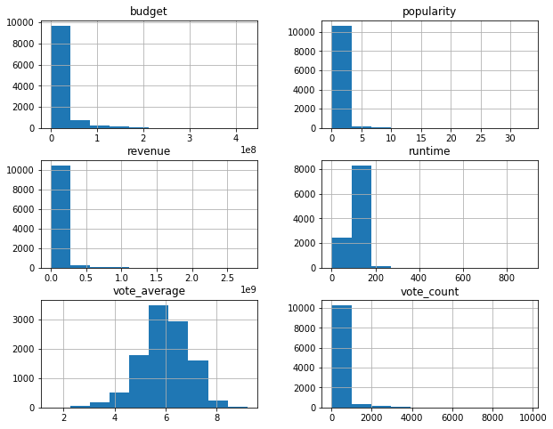

```python
df.hist(figsize=(10,8)); # histogram for all columns.
```

```python
df.info()
```

```
<class 'pandas.core.frame.DataFrame'>
RangeIndex: 10866 entries, 0 to 10865
Data columns (total 7 columns):
 #   Column        Non-Null Count  Dtype
---  ------        --------------  -----
 0   popularity    10866 non-null  float64
 1   budget        10866 non-null  int64
 2   revenue       10866 non-null  int64
 3   runtime       10866 non-null  int64
 4   release_date  10866 non-null  datetime64[ns]
 5   vote_count    10866 non-null  int64
 6   vote_average  10866 non-null  float64
dtypes: datetime64[ns](1), float64(2), int64(4)
memory usage: 594.3 KB
```

Now our data doesn't have any missing values and all data type are correct.

## Exploratory Data Analysis

### what are the characteristics that make a movie has higher revenues?

```python
df.describe()
```

|  | popularity | budget | revenue | runtime | vote_count | vote_average |
| --- | --- | --- | --- | --- | --- | --- |
| count | 10866.000000 | 1.086600e+04 | 1.086600e+04 | 10866.000000 | 10866.000000 | 10866.000000 |
| mean | 0.646441 | 1.462570e+07 | 3.982332e+07 | 102.070863 | 217.389748 | 5.974922 |
| std | 1.000185 | 3.091321e+07 | 1.170035e+08 | 31.381405 | 575.619058 | 0.935142 |
| min | 0.000065 | 0.000000e+00 | 0.000000e+00 | 0.000000 | 10.000000 | 1.500000 |
| 25% | 0.207583 | 0.000000e+00 | 0.000000e+00 | 90.000000 | 17.000000 | 5.400000 |
| 50% | 0.383856 | 0.000000e+00 | 0.000000e+00 | 99.000000 | 38.000000 | 6.000000 |
| 75% | 0.713817 | 1.500000e+07 | 2.400000e+07 | 111.000000 | 145.750000 | 6.600000 |
| max | 32.985763 | 4.250000e+08 | 2.781506e+09 | 900.000000 | 9767.000000 | 9.200000 |

We can see 50% of budget and revenue are 0 ! this can effect the accuarcy of the analysis

```python
df_zero=df.query('budget == 0 and revenue == 0 ') # to get the records that have budget and revenue = 0
df_zero.shape
```

```
(4701, 7)
```

4701 records have budget and revneue = 0 !! , This will effect the accuarcy of the analysis. Because number of records is huge we can't replace the 0 with the average, to get accuare result I will agnore these records to answer my qustion 'what are the characteristics that make a movie has higher revenues?'

```python
df_not_zero=df.query('budget != 0 and revenue != 0 ') # to get the records that doesn't have budget and revenue = 0
df_not_zero.shape
```

```
(3855, 7)
```

#### Now I will compare Revenue with Run Time.

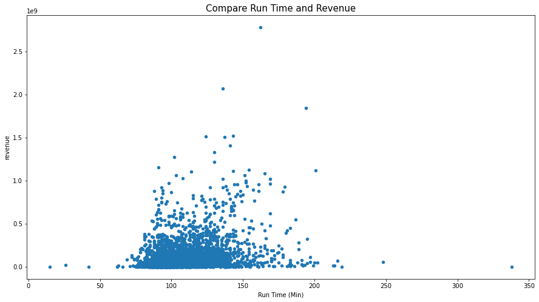

```python
p=df_not_zero.plot(x='runtime',y='revenue',kind="scatter",figsize=(15,8));
p.set_title("Compare Run Time and Revenue", fontsize = 15)
p.set_xlabel("Run Time (Min)");
```

We can see that the movies that are less than 50 min and more than 210 min are usually don't have high revenue.

#### Now I will compare Revenue with vote_count.

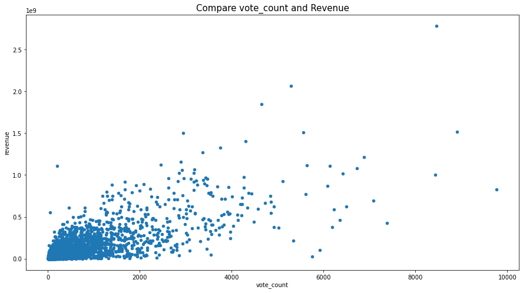

```python
p1=df_not_zero.plot(x='vote_count',y='revenue',kind="scatter",figsize=(15,8));
p1.set_title("Compare vote_count and Revenue", fontsize = 15)
```

We can see the movies that have less amount of vote has less revenue than the ones who has higher amount of votes. howerver I think there is better way to shows this , by devide the vote_count and take the avearge of revenue then represent it in bar chart.

```python
# get the aveatge revenue for each group
less_than_2000 = df_not_zero.query('vote_count <=2000').mean()['revenue']
between_2000_4000 = df_not_zero.query('vote_count > 2000 and vote_count <=4000').mean()['revenue']
between_4000_6000 = df_not_zero.query('vote_count > 4000 and vote_count <=6000').mean()['revenue']
between_6000_8000 = df_not_zero.query('vote_count > 4000 and vote_count <=6000').mean()['revenue']
between_8000_10000 = df_not_zero.query('vote_count > 8000 and vote_count <=10000').mean()['revenue']
```

[figure not shown]

```python
# bar chart
plt.figure(figsize=(15,8))
plt.bar(['>=2000','between_2000_4000','between_4000_6000','between_6000_8000','between_8000_10000'],[less_than_2000,between_2000_4000,between_4000_6000,between_6000_8000,between_8000_10000])
plt.title('Compare vote_count and Revenue')
plt.xlabel('Vote Count')
plt.ylabel('avg Revenue');
```

As we expect the movies who have high vote count have more reveneue.

#### Now I will compare Revenue with Votes

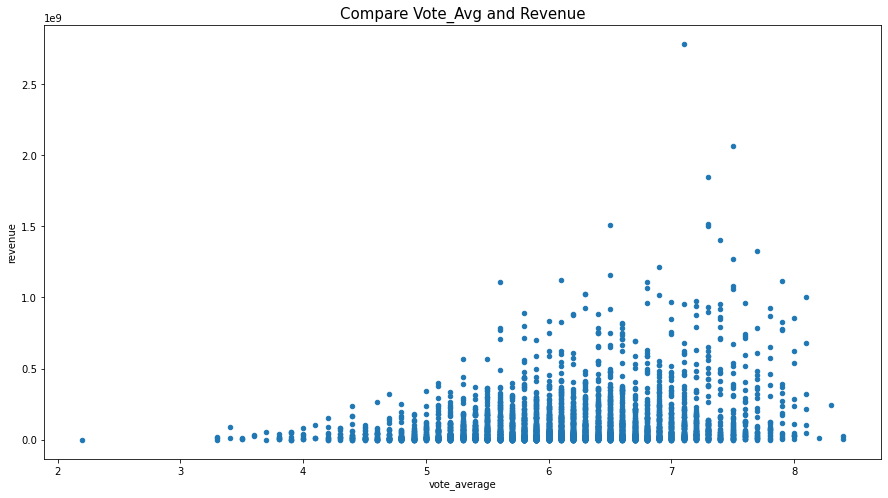

```python
p3=df_not_zero.plot(x='vote_average',y='revenue',kind="scatter",figsize=(15,8))
p3.set_title("Compare Vote_Avg and Revenue", fontsize = 15);
```

We can see the movies that have less vote has less revenue than the ones who has higher votes. also I will do the same thing I will represent this in bar chart.

```python
df_not_zero.vote_average.min() # get minimum of vote
```

```
2.2
```

```python
df_not_zero.vote_average.max() # get maximum of vote
```

```
8.4
```

We can see the minimum of vote is 2.2 and the max is 8.4 , so I will take the average of revenue based the follwing ranges of vote:

- 2.2 to 3.2
- 3.3 to 4.2
- 4.3 to 5.2
- 5.3 to 6.2
- 6.3 to 7.2
- 7.3 to 8.5

```python
# get the aveatge revenue for each group
between_2_to_3= df_not_zero.query('vote_average >= 2.2 and 3.2>= vote_average').mean()['revenue']
between_3_to_4= df_not_zero.query('vote_average >= 3.3 and 4.2>= vote_average').mean()['revenue']
between_4_to_5= df_not_zero.query('vote_average >= 4.3 and 5.2>= vote_average').mean()['revenue']
between_5_to_6= df_not_zero.query('vote_average >= 5.3 and 6.2>= vote_average').mean()['revenue']
between_6_to_7= df_not_zero.query('vote_average >= 6.3 and 7.2>= vote_average').mean()['revenue']
between_7_to_8= df_not_zero.query('vote_average >= 7.3 and 8.5>= vote_average').mean()['revenue']
```

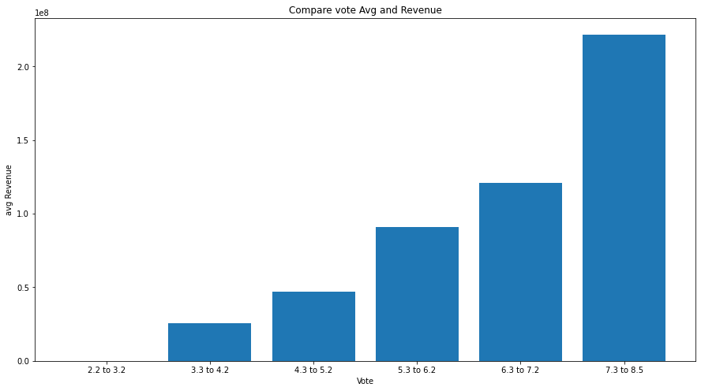

```python
# bar chart
plt.figure(figsize=(15,8))
plt.bar(['2.2 to 3.2','3.3 to 4.2','4.3 to 5.2','5.3 to 6.2','6.3 to 7.2','7.3 to 8.5'],[between_2_to_3,between_3_to_4,between_4_to_5,between_5_to_6,between_6_to_7,between_7_to_8])
plt.title('Compare vote Avg and Revenue')
plt.xlabel('Vote')
plt.ylabel('avg Revenue');
```

#### Now I will compare Revenue with the budget

```python
df_not_zero.budget.median() # get the median of the budget
```

```
24000000.0
```

```python
above=df.query('budget >= 24000000.0') # above or equal to the median
under=df.query('budget < 24000000.0') # under the median
```

```python
above.revenue.mean() # get the average for the budget that above the median.
```

```
158509143.68527204
```

```python
under.revenue.mean() # get the average for the budget that under the median.
```

```
10851694.359743532
```

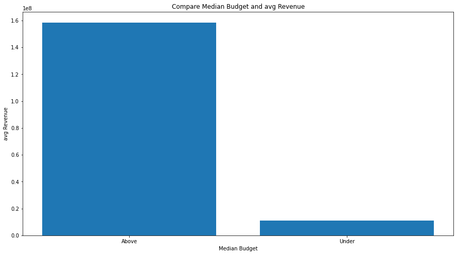

```python
# bar chart
plt.figure(figsize=(15,8))
plt.bar(['Above','Under'],[above.revenue.mean(),under.revenue.mean()])
plt.title('Compare Median Budget and avg Revenue')
plt.xlabel('Median Budget')
plt.ylabel('avg Revenue');
```

As we see the movies that spend on the budget more, get more revenue.

### what are the characteristics that make a movie has higher votes?

```python
votes_median=df.vote_average.median() # get the median of votes
print(votes_median)
```

```
6.0
```

```python
High_votes = df.query('vote_average >= 6.0')
Low_votes = df.query('vote_average < 6.0')
High_votes.budget.mean() # get budget average
```

```
16427332.555421688
```

```python
Low_votes.budget.mean() # get budget average
```

```
12555392.789161392
```

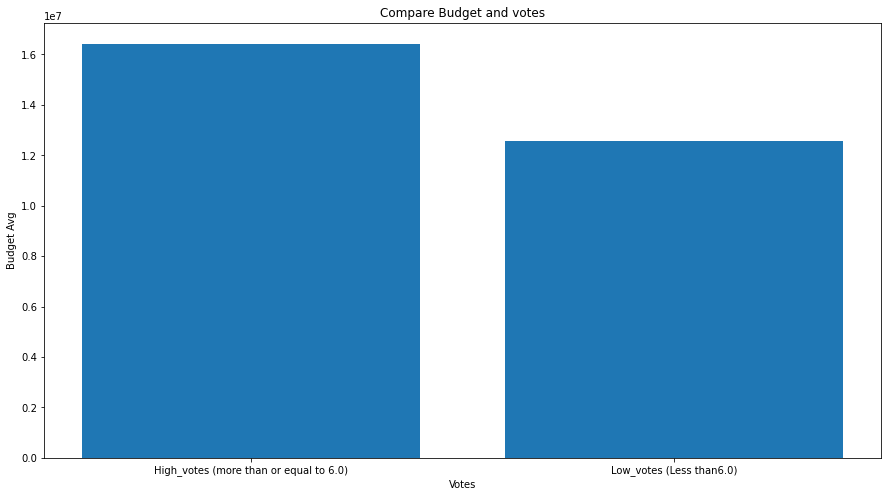

```python
plt.figure(figsize=(15,8))
plt.bar(['High_votes (more than or equal to 6.0)','Low_votes (Less than6.0)'],[High_votes.budget.mean(),Low_votes.budget.mean()])
plt.title('Compare Budget and votes')
plt.xlabel('Votes')
plt.ylabel('Budget Avg');
```

We can see the movies that get higher votes spend more money on the movie.

```python
High_votes.revenue.mean() # get revenue average.
```

```
55311962.61824441
```

```python
Low_votes.revenue.mean() # get revenue average.
```

```
22024859.58524525
```

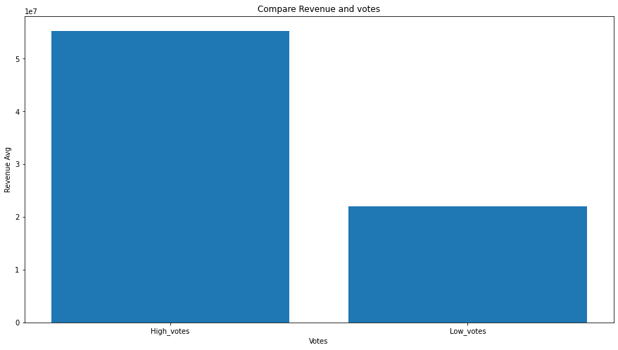

```python
plt.figure(figsize=(15,8))
plt.bar(['High_votes','Low_votes'],[High_votes.revenue.mean(),Low_votes.revenue.mean()])
plt.title('Compare Revenue and votes')
plt.xlabel('Votes')
plt.ylabel('Revenue Avg');
```

as expected, We can see the movies that get high votes get more revenue.

```python
High_votes.popularity.mean()
```

```
0.7927575848537005
```

```python
Low_votes.popularity.mean()
```

```
0.4783041566455695
```

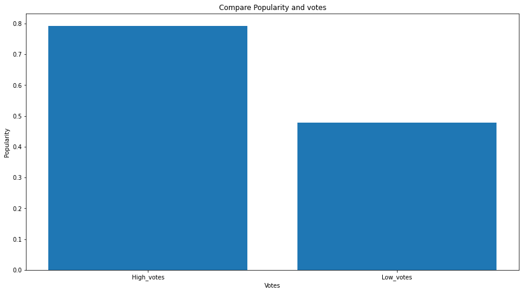

```python
plt.figure(figsize=(15,8))
plt.bar(['High_votes','Low_votes'],[High_votes.popularity.mean(),Low_votes.popularity.mean()])
plt.title('Compare Popularity and votes')
plt.xlabel('Votes')
plt.ylabel('Popularity');
```

as expected, We can see the movies that get high votes are more popular.

## How the characteristics of the movie changed over time ?

Now I want to see how the characteristics of the movie changed over time.

```python
df_not_zero.release_date.describe()
```

```
count                    3855
unique                   2885
top       2014-12-25 00:00:00
freq                        7
first     1970-01-24 00:00:00
last      2069-12-12 00:00:00
Name: release_date, dtype: object
```

We can see last relase date is not correct (2069-12-12).

```python
sum(df_not_zero.release_date.dt.year >=2021) # to get number of relase dates that not correct.
```

```
71
```

```python
correct_dates_df= df_not_zero.query('release_date.dt.year <=2021') # to get only the movies with correct relase date.
correct_dates_df.release_date.describe()
```

```
count                    3784
unique                   2814
top       2014-12-25 00:00:00
freq                        7
first     1970-01-24 00:00:00
last      2015-12-30 00:00:00
Name: release_date, dtype: object
```

```python
# I save it to csv to use excel to calculate moving average for budget and revene
correct_dates_df.to_csv('add_moving_average.csv',index=False)
```

```python
moving_avg_df = pd.read_csv('add_moving_average.csv') # load dataset after adding moving average.
```

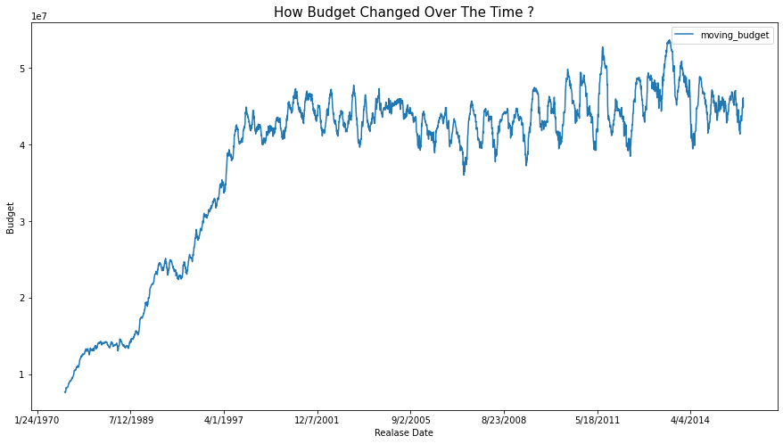

```python
p4 = moving_avg_df.plot(x='release_date',y='moving_budget',kind="line",figsize=(15,8));
p4.set_title("How Budget Changed Over The Time ?", fontsize = 15)
p4.set_xlabel("Realase Date");
p4.set_ylabel("Budget");
```

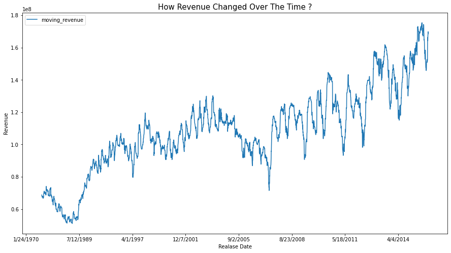

```python
p5 = moving_avg_df.plot(x='release_date',y='moving_revenue',kind="line",figsize=(15,8));
p5.set_title("How Revenue Changed Over The Time ?", fontsize = 15)
p5.set_xlabel("Realase Date");
p5.set_ylabel("Revenue");
```

Also the revenue for the movies is increasing over the time

## Conclusions

### Q2: what are the characteristics that make a movie has higher votes?

- When the movie have high revenue the vote will be high (6.0 or more)
- When the movie have high budget the vote will be high (6.0 or more)
- When the movie is more popular the vote will be high (6.0 or mroe)